# Problem Statement - Credit Card Users Churn Prediction

#### Distribution of **`Education_Level`** *(Categorical Column)*

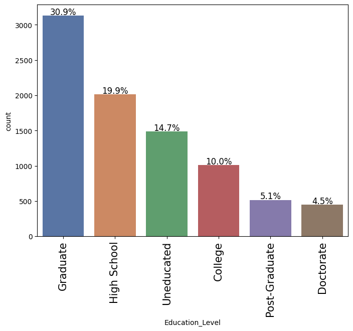

```python
labeled_barplot(df, 'Education_Level', perc=True);
```

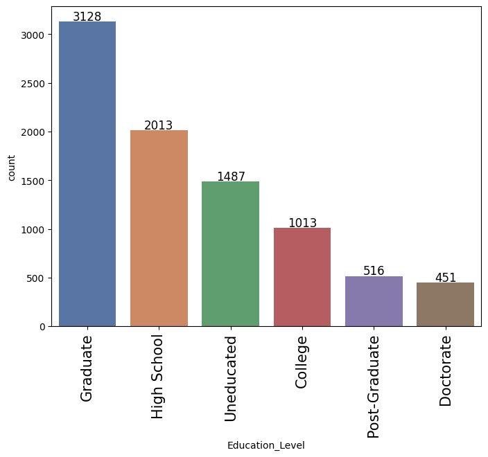

```python
labeled_barplot(df, 'Education_Level');
```

##### Observations:

- The majority of customers have a *Graduate* (31%) or *High School* (20%) education, while only a small percentage hold a *Doctorate* (4%).
- A significant portion of customers (15%) are *Uneducated*, which may impact financial literacy and credit-related decisions.

#### Distribution of **`Marital_Status`** *(Categorical Column)*

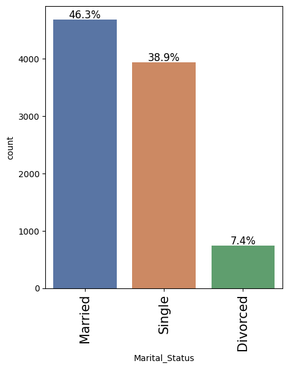

```python
labeled_barplot(df, 'Marital_Status', perc=True);
```

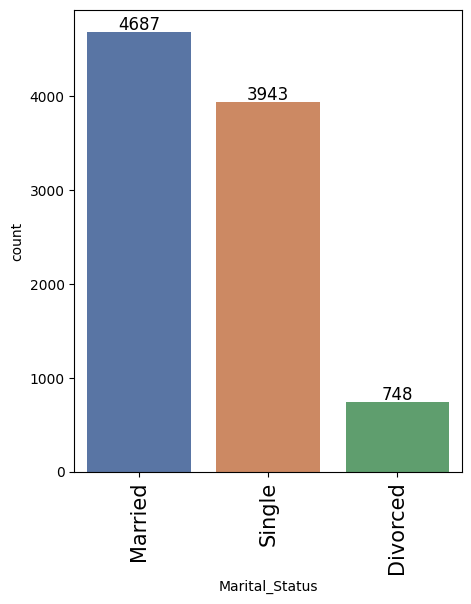

```python
labeled_barplot(df, 'Marital_Status');
```

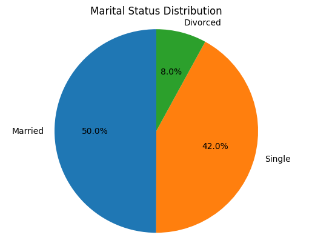

```python
plt.pie(df['Marital_Status'].value_counts(), labels=df['Marital_Status'].value_counts().index, autopct='%1.1f%%', startangle=90)
plt.title('Marital Status Distribution')
plt.axis('equal');
```

##### Observations:

### **Observations on Marital_Status**

- **Majority are Married:** Most customers are *Married* (4687), followed by *Single* (3943), while *Divorced* customers form the smallest group (748).

#### Distribution of **`Income_Category`** *(Categorical Column)*

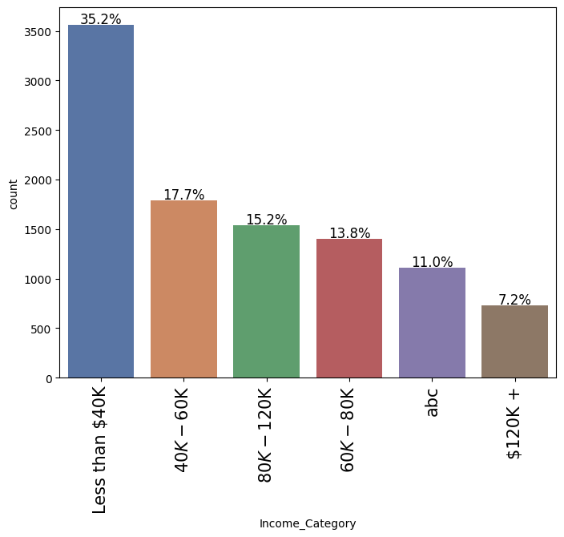

```python
labeled_barplot(df, 'Income_Category', perc=True);
```

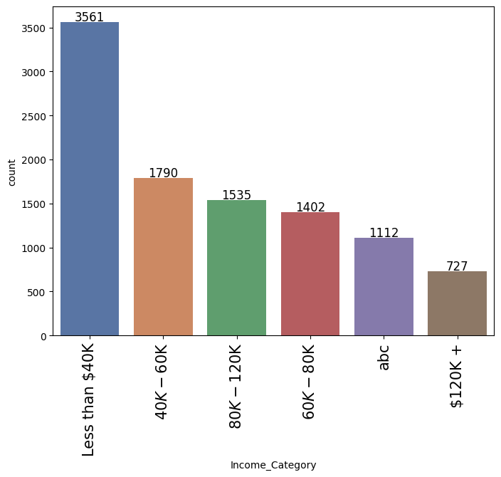

```python
labeled_barplot(df, 'Income_Category');
```

##### Observations:

- **Majority of Customers:** Most customers fall in the *Less than $40K* income category (3561), indicating a significant portion of lower-income users.
- **Data Inconsistency:** The category **"abc"** (1112) appears to be an invalid entry, requiring data cleaning or imputation to ensure model accuracy.

#### Distribution of **`Card_Category`** *(Categorical Column)*

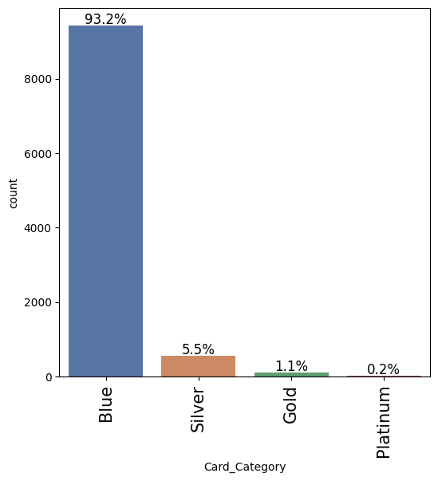

```python
labeled_barplot(df, 'Card_Category', perc=True);
```

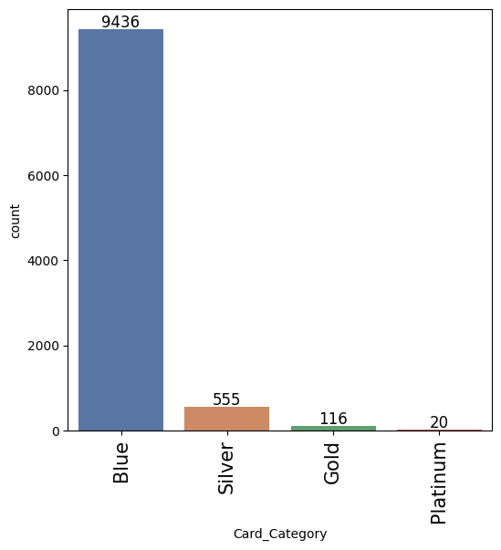

```python
labeled_barplot(df, 'Card_Category');
```

##### Observations:

- **Highly Imbalanced Distribution:** The majority of customers hold the *Blue* card (9436), while higher-tier cards (*Silver, Gold, Platinum*) have significantly fewer users.
- **Potential Business Insight:** The low number of *Gold* (116) and *Platinum* (20) cardholders may indicate limited offerings or higher eligibility criteria, which could be explored for potential marketing strategies.

### Bivariate analysis

#### Distribution of **`Attrition_Flag`** vs **`Dependent_count`** *(Categorical column & Numerical Column)*

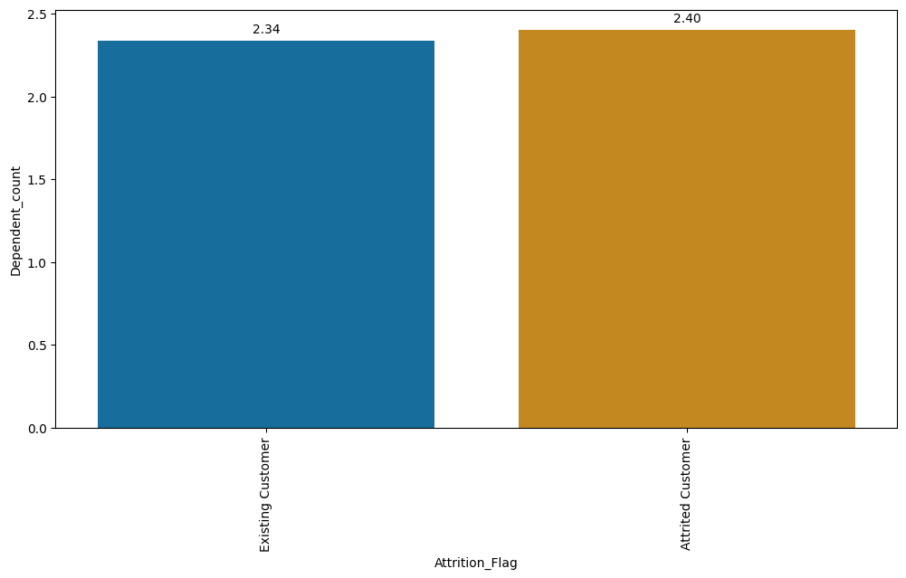

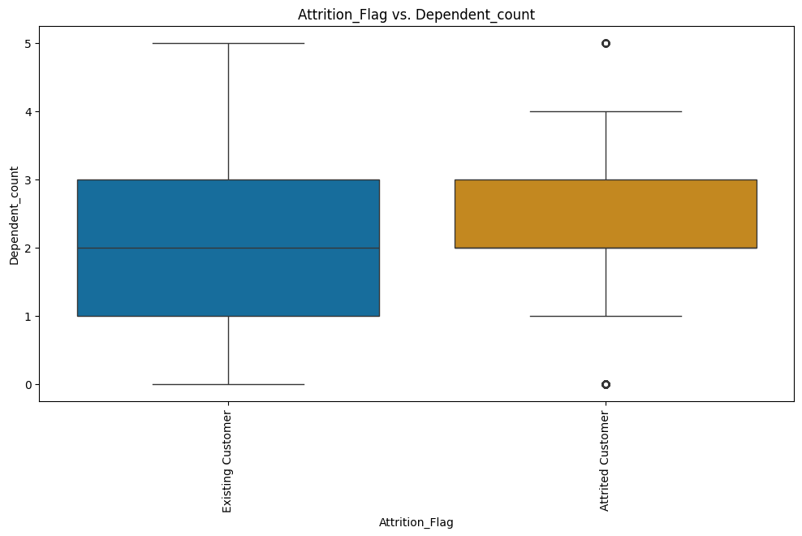

```python
barplot(df, 'Attrition_Flag', 'Dependent_count');
```

##### Observations:

- Attrited customers tend to have a slightly higher average number of dependents compared to existing customers (2.40 vs. 2.34). However, the distributions in the box plot indicate that both groups have a similar spread of dependent counts, suggesting that dependent count may not be a strong differentiating factor for customer attrition.

#### Distribution of **`Attrition_Flag`** vs **`Months_on_book`** *(Categorical column & Numerical Column)*

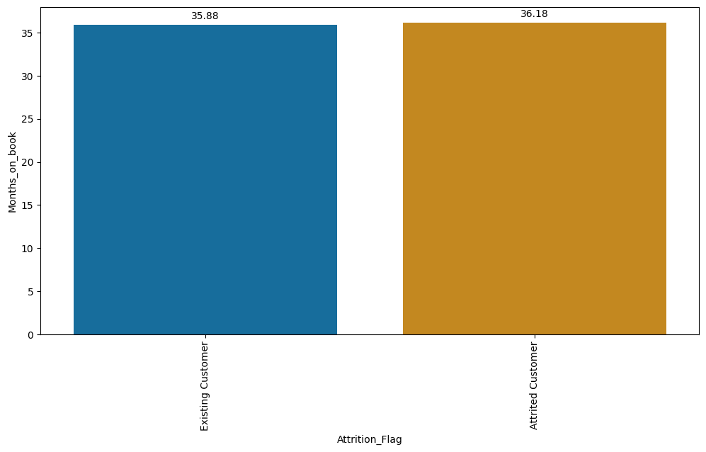

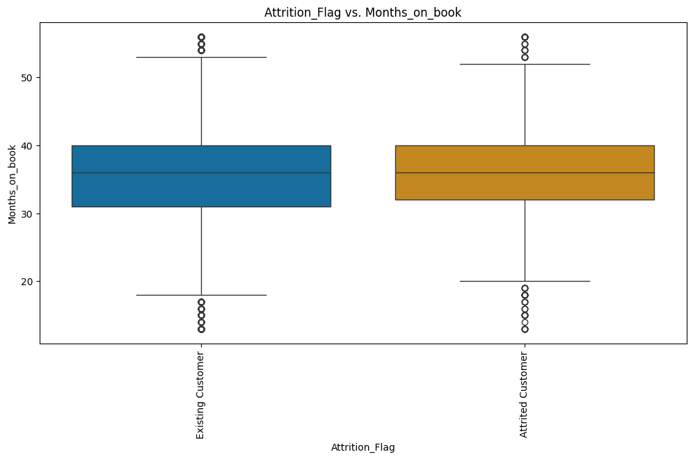

```python
barplot(df, 'Attrition_Flag', 'Months_on_book');
```

##### Observations:

- The median number of months a customer stays before attrition is almost the same for both existing and attrited customers. This suggests that "Months_on_book" may not be a strong differentiator for customer attrition.

#### Distribution of **`Attrition_Flag`** vs **`Total_Relationship_Count`** *(Categorical column & Numerical Column)*

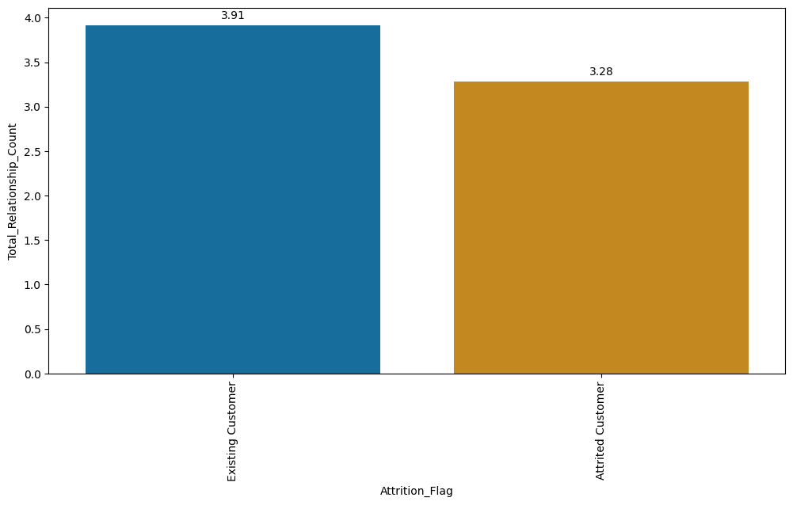

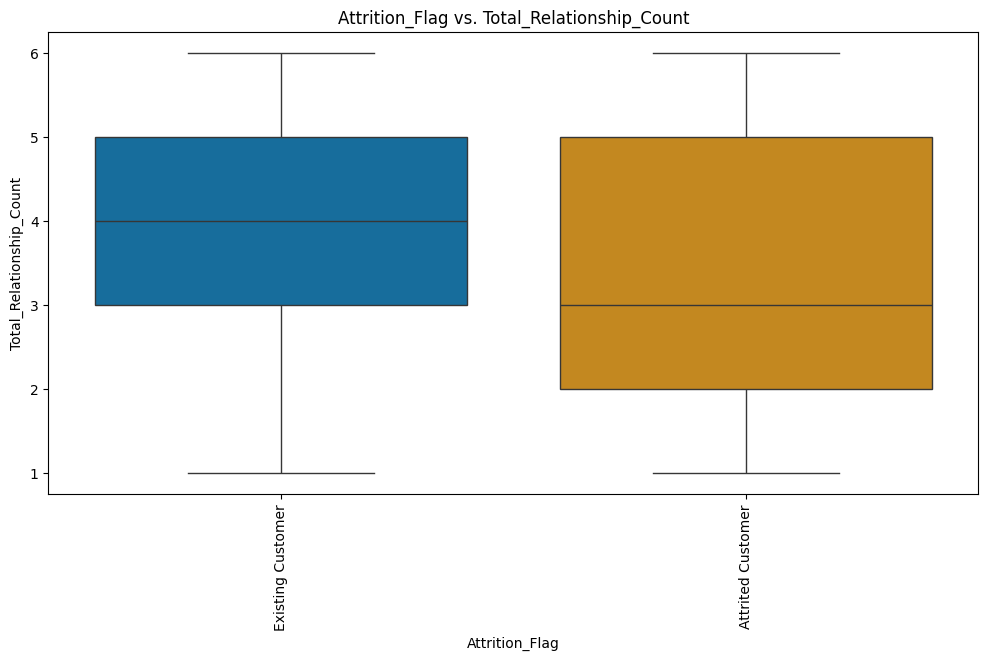

```python
barplot(df, 'Attrition_Flag', 'Total_Relationship_Count');
```

##### Observations:

- From both the bar chart and box plot, it is evident that Existing Customers have a higher average Total Relationship Count (3.91) compared to Attrited Customers (3.28).

#### Distribution of **`Attrition_Flag`** vs **`Months_Inactive_12_mon`** *(Categorical column & Numerical Column)*

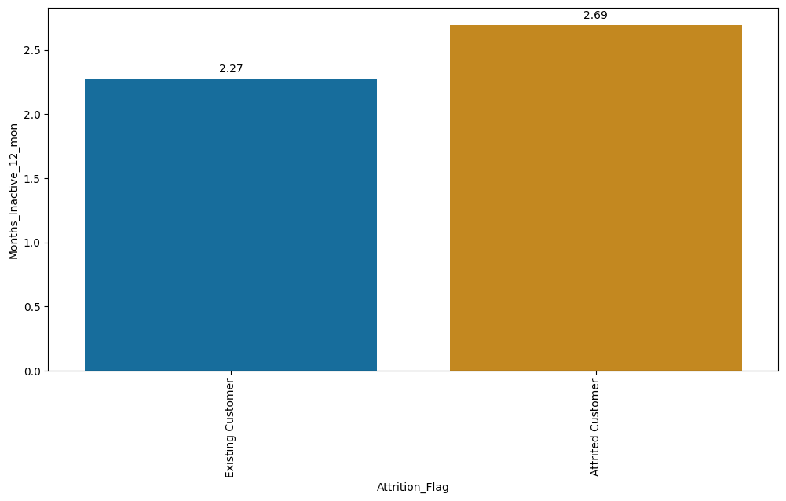

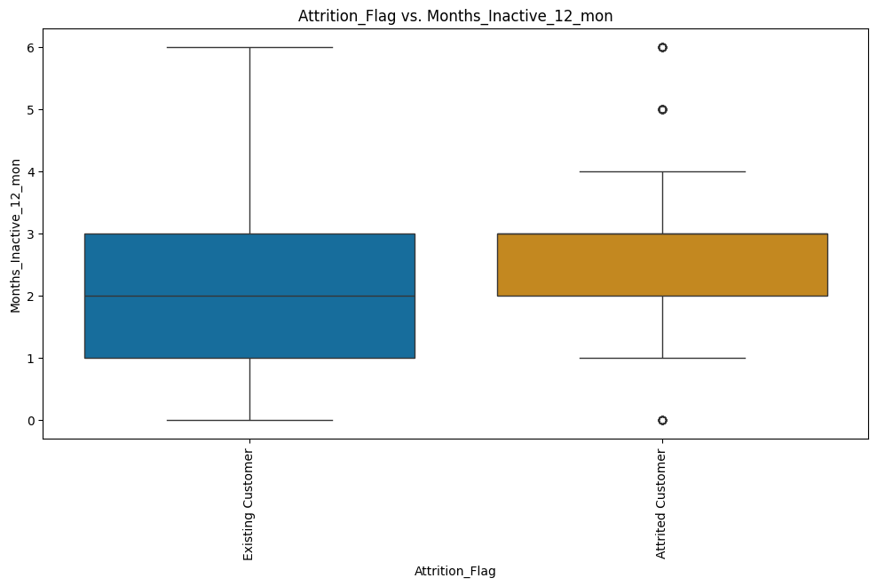

```python
barplot(df, 'Attrition_Flag', 'Months_Inactive_12_mon');
```

#### Distribution of **`Attrition_Flag`** vs **`Contacts_Count_12_mon`** *(Categorical column & Numerical Column)*

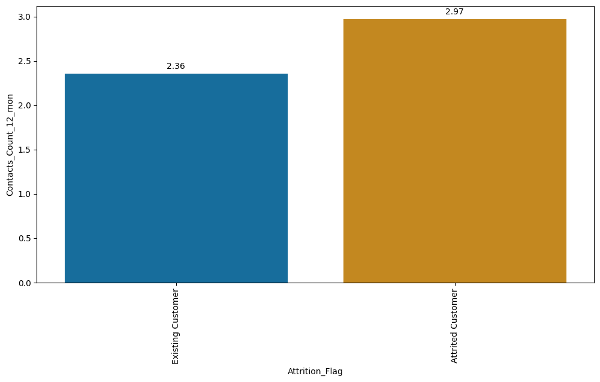

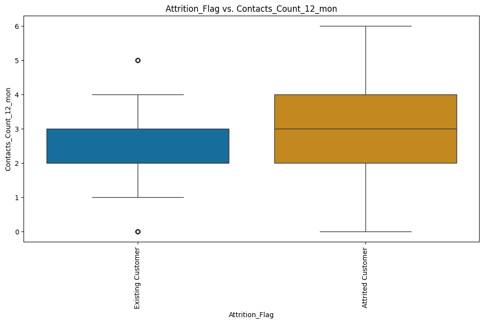

```python
barplot(df, 'Attrition_Flag', 'Contacts_Count_12_mon');
```

#### Distribution of **`Attrition_Flag`** vs **`Credit_Limit`** *(Categorical column & Numerical Column)*

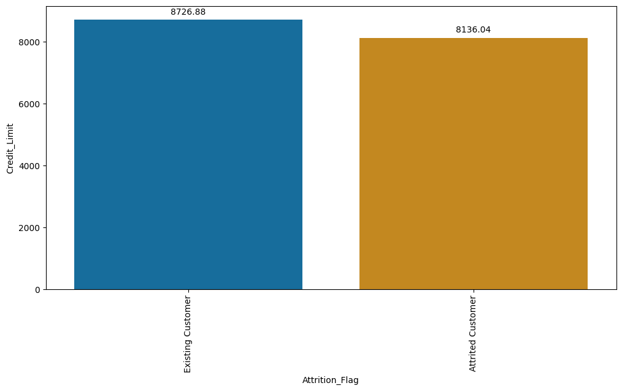

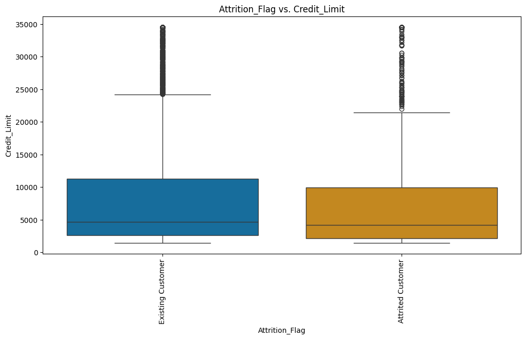

```python
barplot(df, 'Attrition_Flag', 'Credit_Limit');
```

##### Observations:

- Existing customers generally have a higher average credit limit (8726.88) than attrited customers (8136.04), but the distribution shows that both groups have a significant number of outliers, indicating high variability in credit limits.

#### Distribution of **`Attrition_Flag`** vs **`Total_Revolving_Bal`** *(Categorical column & Numerical Column)*

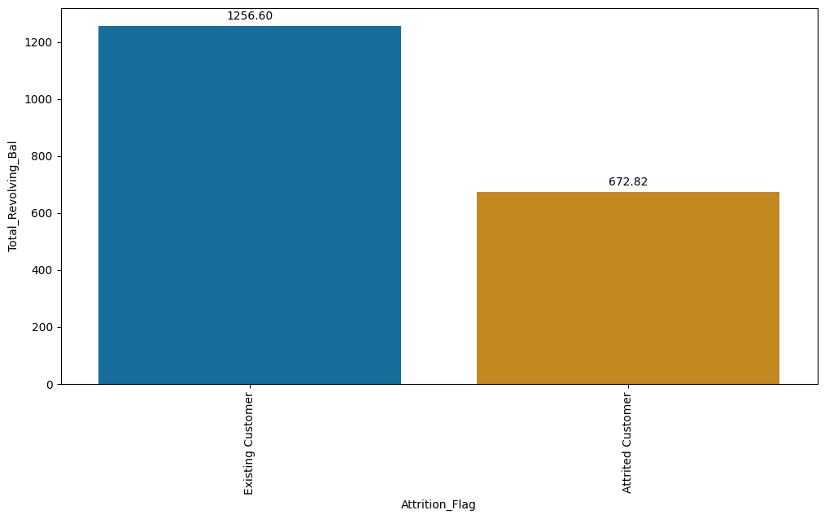

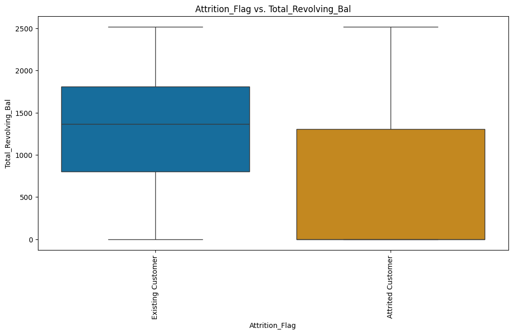

```python
barplot(df, 'Attrition_Flag', 'Total_Revolving_Bal');
```

##### Observations:

- Existing customers have a significantly higher Total Revolving Balance than attrited customers.

#### Distribution of **`Attrition_Flag`** vs **`Avg_Open_To_Buy`** *(Categorical column & Numerical Column)*

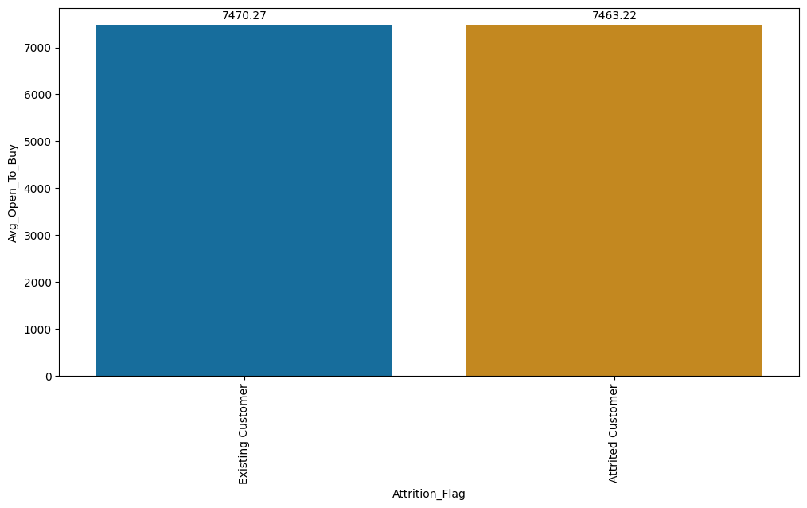

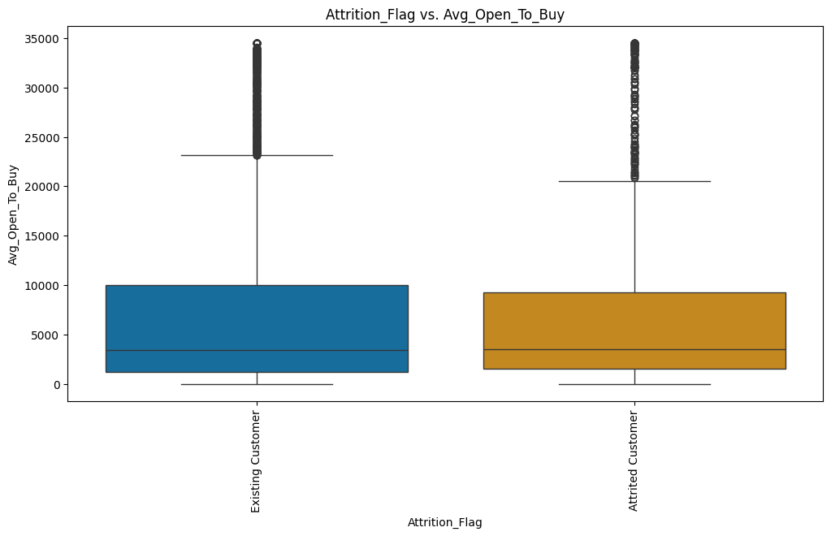

```python
barplot(df, 'Attrition_Flag', 'Avg_Open_To_Buy');
```

##### Observations:

- The average "Open To Buy" amount is nearly identical for both Existing and Attrited Customers (~7470). This suggests that, on average, available credit is not a distinguishing factor between these two groups.

#### Distribution of **`Attrition_Flag`** vs **`Total_Amt_Chng_Q4_Q1`** *(Categorical column & Numerical Column)*

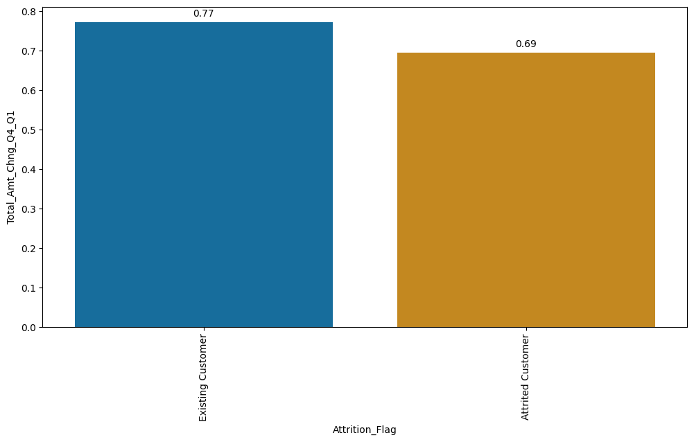

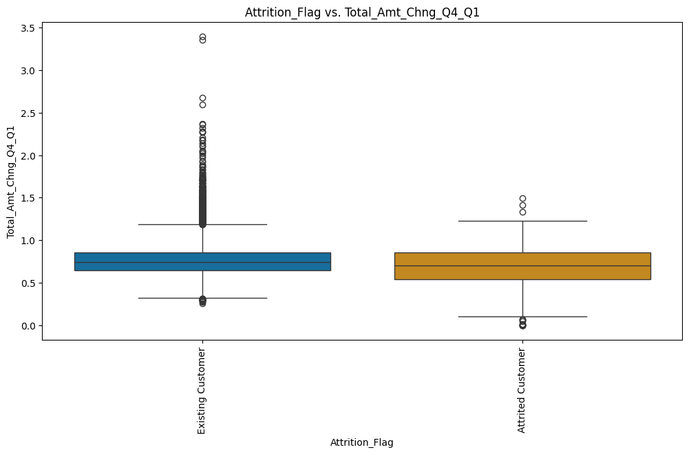

```python
barplot(df, 'Attrition_Flag', 'Total_Amt_Chng_Q4_Q1');
```

##### Observations:

- Based on above graph & plot, Existing customers have a higher average change in total transaction amount (Total_Amt_Chng_Q4_Q1) compared to attrited customers

#### Distribution of **`Attrition_Flag`** vs **`Total_Trans_Amt`** *(Categorical column & Numerical Column)*

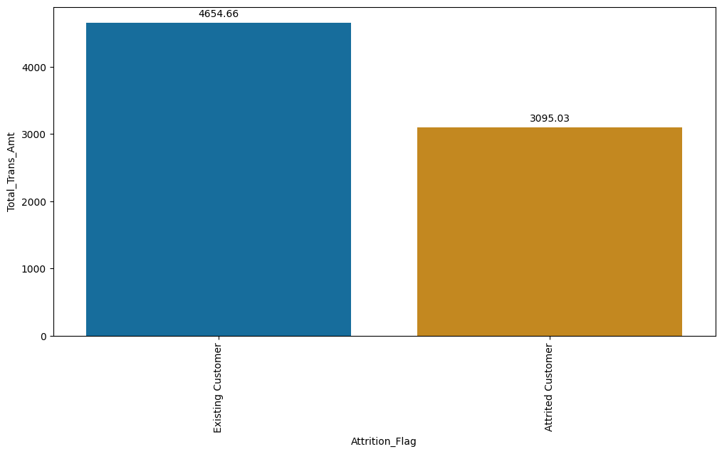

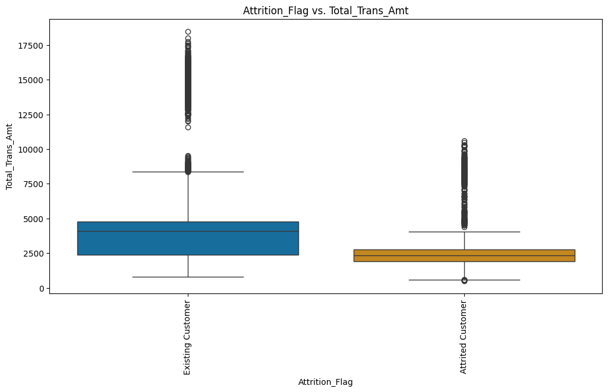

```python
barplot(df, 'Attrition_Flag', 'Total_Trans_Amt');
```

##### Observations:

- Based on observations, Existing customers have significantly higher total transaction amounts compared to attrited customers.

### Multivariate analysis

#### Visualizing Relationships Across Multiple Variables

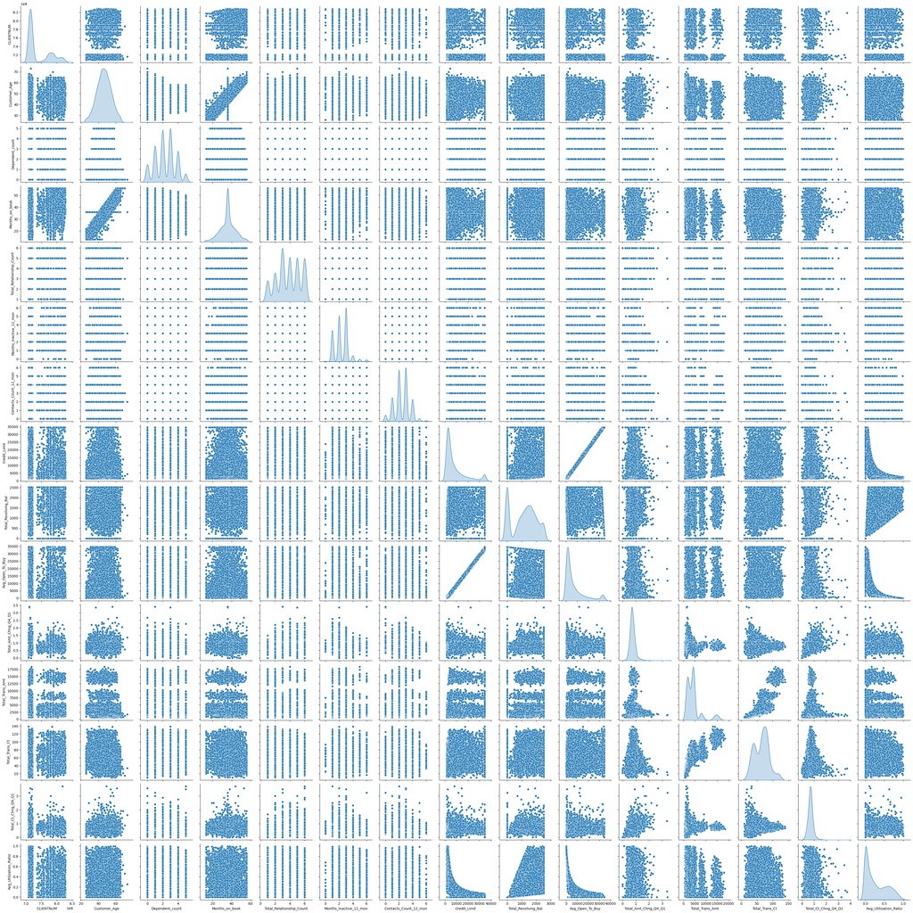

```python
sns.pairplot(data=df[numerical_col], diag_kind='kde');
```

#### Checking Correlation Between Multiple Variables

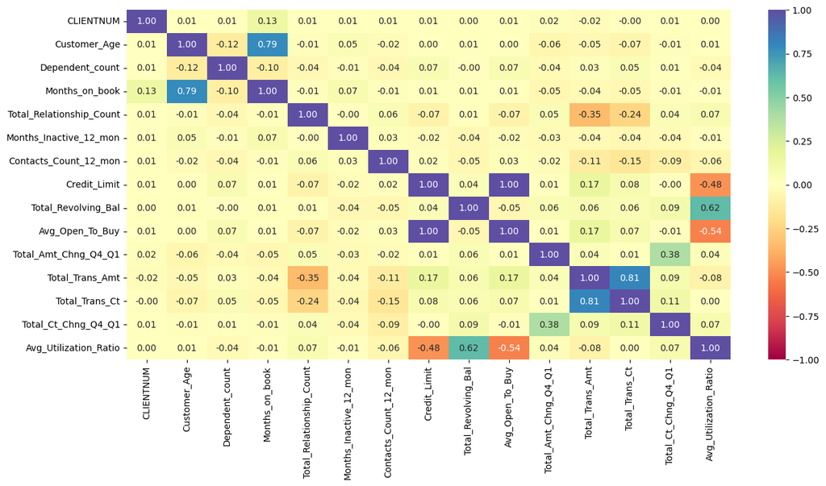

```python
plt.figure(figsize=(15, 7))
sns.heatmap(df.corr(numeric_only=True), annot=True, vmin=-1, vmax=1, fmt=".2f", cmap="Spectral")
plt.show()
```

## **Data Preprocessing**

#### **Checking for null values**

```python
# Calculate the percentage of missing values
missing_percentage = round(df.isnull().sum() / df.isnull().count() * 100, 2)

# Calculate the count of missing values
missing_count = df.isna().sum()

# Combine both into a single DataFrame
missing_summary = pd.DataFrame({
    'Missing Count': missing_count,
    'Missing Percentage': missing_percentage
})

# Display the result
print(missing_summary)
```

```
                          Missing Count  Missing Percentage
CLIENTNUM                             0               0.000
Attrition_Flag                        0               0.000
Customer_Age                          0               0.000
Gender                                0               0.000
Dependent_count                       0               0.000
Education_Level                    1519              15.000
Marital_Status                      749               7.400
Income_Category                       0               0.000
Card_Category                         0               0.000
Months_on_book                        0               0.000
Total_Relationship_Count              0               0.000
Months_Inactive_12_mon                0               0.000
Contacts_Count_12_mon                 0               0.000
Credit_Limit                          0               0.000
Total_Revolving_Bal                   0               0.000
Avg_Open_To_Buy                       0               0.000
Total_Amt_Chng_Q4_Q1                  0               0.000
Total_Trans_Amt                       0               0.000
Total_Trans_Ct                        0               0.000
Total_Ct_Chng_Q4_Q1                   0               0.000
Avg_Utilization_Ratio                 0               0.000
```

##### Observations:

- As we can see, 1519 missing data in `Education_Level` column & 749 missing data in `Marital_Status` columns.

#### **Checking for duplicate values**

```python
df.duplicated().sum()
```

```
0
```

##### Observations:

- There are *`no duplicate`* values in the data.

#### **Number of unique columns**

```python
df.nunique()
```

|  | 0 |
| --- | --- |
| CLIENTNUM | 10127 |
| Attrition_Flag | 2 |
| Customer_Age | 45 |
| Gender | 2 |
| Dependent_count | 6 |
| Education_Level | 6 |
| Marital_Status | 3 |
| Income_Category | 6 |
| Card_Category | 4 |
| Months_on_book | 44 |
| Total_Relationship_Count | 6 |
| Months_Inactive_12_mon | 7 |
| Contacts_Count_12_mon | 7 |
| Credit_Limit | 6205 |
| Total_Revolving_Bal | 1974 |
| Avg_Open_To_Buy | 6813 |
| Total_Amt_Chng_Q4_Q1 | 1158 |
| Total_Trans_Amt | 5033 |
| Total_Trans_Ct | 126 |
| Total_Ct_Chng_Q4_Q1 | 830 |
| Avg_Utilization_Ratio | 964 |

**dtype:** int64

```python
df['CLIENTNUM'].nunique()
```

```
10127
```

```python
df.head()
```

|  | CLIENTNUM | Attrition_Flag | Customer_Age | Gender | Dependent_count | Education_Level | Marital_Status | Income_Category | Card_Category | Months_on_book | Total_Relationship_Count | Months_Inactive_12_mon | Contacts_Count_12_mon | Credit_Limit | Total_Revolving_Bal | Avg_Open_To_Buy | Total_Amt_Chng_Q4_Q1 | Total_Trans_Amt | Total_Trans_Ct | Total_Ct_Chng_Q4_Q1 | Avg_Utilization_Ratio |
| --- | --- | --- | --- | --- | --- | --- | --- | --- | --- | --- | --- | --- | --- | --- | --- | --- | --- | --- | --- | --- | --- |
| 0 | 768805383 | Existing Customer | 45 | M | 3 | High School | Married | $60K - $80K | Blue | 39 | 5 | 1 | 3 | 12691.000 | 777 | 11914.000 | 1.335 | 1144 | 42 | 1.625 | 0.061 |
| 1 | 818770008 | Existing Customer | 49 | F | 5 | Graduate | Single | Less than $40K | Blue | 44 | 6 | 1 | 2 | 8256.000 | 864 | 7392.000 | 1.541 | 1291 | 33 | 3.714 | 0.105 |
| 2 | 713982108 | Existing Customer | 51 | M | 3 | Graduate | Married | $80K - $120K | Blue | 36 | 4 | 1 | 0 | 3418.000 | 0 | 3418.000 | 2.594 | 1887 | 20 | 2.333 | 0.000 |
| 3 | 769911858 | Existing Customer | 40 | F | 4 | High School | NaN | Less than $40K | Blue | 34 | 3 | 4 | 1 | 3313.000 | 2517 | 796.000 | 1.405 | 1171 | 20 | 2.333 | 0.760 |
| 4 | 709106358 | Existing Customer | 40 | M | 3 | Uneducated | Married | $60K - $80K | Blue | 21 | 5 | 1 | 0 | 4716.000 | 0 | 4716.000 | 2.175 | 816 | 28 | 2.500 | 0.000 |

##### Observations:

```python
# As the CLIENTNUM has unique values we can drop the CLIENTNUM column from the data frame.
df = df.drop(labels="CLIENTNUM", axis=1)
df.head()
```

|  | Attrition_Flag | Customer_Age | Gender | Dependent_count | Education_Level | Marital_Status | Income_Category | Card_Category | Months_on_book | Total_Relationship_Count | Months_Inactive_12_mon | Contacts_Count_12_mon | Credit_Limit | Total_Revolving_Bal | Avg_Open_To_Buy | Total_Amt_Chng_Q4_Q1 | Total_Trans_Amt | Total_Trans_Ct | Total_Ct_Chng_Q4_Q1 | Avg_Utilization_Ratio |
| --- | --- | --- | --- | --- | --- | --- | --- | --- | --- | --- | --- | --- | --- | --- | --- | --- | --- | --- | --- | --- |
| 0 | Existing Customer | 45 | M | 3 | High School | Married | $60K - $80K | Blue | 39 | 5 | 1 | 3 | 12691.000 | 777 | 11914.000 | 1.335 | 1144 | 42 | 1.625 | 0.061 |
| 1 | Existing Customer | 49 | F | 5 | Graduate | Single | Less than $40K | Blue | 44 | 6 | 1 | 2 | 8256.000 | 864 | 7392.000 | 1.541 | 1291 | 33 | 3.714 | 0.105 |
| 2 | Existing Customer | 51 | M | 3 | Graduate | Married | $80K - $120K | Blue | 36 | 4 | 1 | 0 | 3418.000 | 0 | 3418.000 | 2.594 | 1887 | 20 | 2.333 | 0.000 |
| 3 | Existing Customer | 40 | F | 4 | High School | NaN | Less than $40K | Blue | 34 | 3 | 4 | 1 | 3313.000 | 2517 | 796.000 | 1.405 | 1171 | 20 | 2.333 | 0.760 |
| 4 | Existing Customer | 40 | M | 3 | Uneducated | Married | $60K - $80K | Blue | 21 | 5 | 1 | 0 | 4716.000 | 0 | 4716.000 | 2.175 | 816 | 28 | 2.500 | 0.000 |

```python
df.shape
```

```
(10127, 20)
```

##### Observations:

- There are *`20 columns`* (Previously 21 columns) in new data frame.